# Ecologia de peces (Taller individual I)

Kenneth Roy Cabrera Torres

Viernes, 31 de agosto de 2018

## Contextualización

Datos de la tesis doctoral de Verneaux (1973)

Verneaux, J. (1973) Cours d’eau de Franche-Comté (Massif du Jura). Recherches écologiques sur le réseau hydrographique du Doubs. Essai de biotypologie. Thèse d’état, Besançon. 1–257

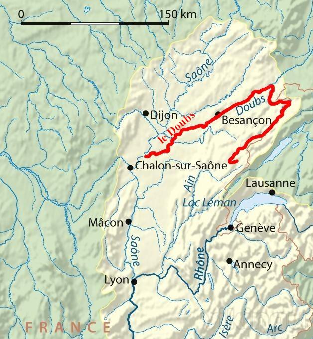

[figure not shown]

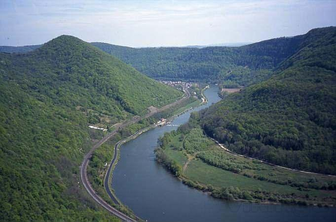

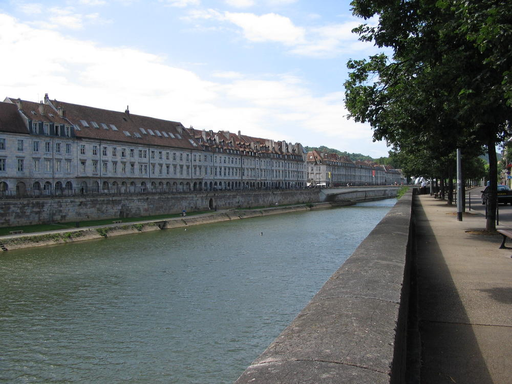

La tesis propone el uso de las especies de peces para caracterizar las zonas ecológicas a lo largo de rios y quebradas de Europa. Él mostró que las comunidades de peces son buenos indicadores biológicos para estos cuerpos de agua. A partir del nacimiento propuso una topología en cuatro zonas, y las designó de acuerdo a las características de las especies como:

- Zona de la trucha (Trout zone)
- Zona del tímalo (Grayling zone)
- Zona del barbo (Barbel zone)
- Zona de la brema (Bream zone)

Las condiciones ecológicas correspondientes, con mucha variación entre los rios, varía desde agua relativamente pristinas, bien oxigendadas y oligotróficas hasta eutróficas y sin oxígeno.

Los datos se tomaron en 30 lugares a lo largo del río Doubs. Este río corre cerca de la frontera franco-suiza al borde del macizo del Jura.

## Listado de las bases de datos.

- La base de datos de **peces** tienen las abundancias de 27 especies de peces. Cada registro corresponde a uno de los 30 sitios. Las abundancias están reescalada a una medida semicuantitativa de 1 a 5.
- La base de datos **ambientales** tiene 11 variable ambientales relacionadas con la hidrología, la geomorfología y la química del rio.
- La base de datos de **localidades** tiene las coordenadas planas de cada uno de los 30 sitios de muestreo.
- La base de datos **nombre de especies** tiene los códigos, los nombres científicos, los nombres en inglés y en francés de las 27 especies reconocidas en el estudio.
- La base de datos **Nombres de variables ambientales** tiene los códigos de las variables ambientales, la designación completa y las unidades de cada variable.

## Lectura de las bases de datos

```r
ambient<-read.csv2("ambientales.csv",enc="latin1",row.names=1)
peces<-read.csv2("peces.csv",enc="latin1",row.names=1)
locs<-read.csv2("localidades.csv",enc="latin1",row.names=1)
nomEspec<-read.csv2("nombresdeespecies.csv",enc="latin1")
nomVarAmbient<-read.csv2("Nombresdevariablesambientales.csv",enc="latin1")
```

## Análisis descriptivo.

### Abundancia de peces.

Despliegue de la base de datos. (Este procedimiento no es recomendado para grandes base de datos.)

```r
peces
```

```
##    Cogo Satr Phph Neba Thth Teso Chna Chto Lele Lece Baba Spbi Gogo Eslu
## 1     0    3    0    0    0    0    0    0    0    0    0    0    0    0
## 2     0    5    4    3    0    0    0    0    0    0    0    0    0    0
## 3     0    5    5    5    0    0    0    0    0    0    0    0    0    1
## 4     0    4    5    5    0    0    0    0    0    1    0    0    1    2
## 5     0    2    3    2    0    0    0    0    5    2    0    0    2    4
## 6     0    3    4    5    0    0    0    0    1    2    0    0    1    1
## 7     0    5    4    5    0    0    0    0    1    1    0    0    0    0
## 8     0    0    0    0    0    0    0    0    0    0    0    0    0    0
## 9     0    0    1    3    0    0    0    0    0    5    0    0    0    0
## 10    0    1    4    4    0    0    0    0    2    2    0    0    1    0
## 11    1    3    4    1    1    0    0    0    0    1    0    0    0    0
## 12    2    5    4    4    2    0    0    0    0    1    0    0    0    0
## 13    2    5    5    2    3    2    0    0    0    0    0    0    0    0
## 14    3    5    5    4    4    3    0    0    0    1    1    0    1    1
```

[output cut: 47 more lines]

### Resumen de la base de datos de peces

```r
summary(peces)
```

```
##       Cogo           Satr           Phph            Neba
##  Min.   :0.00   Min.   :0.00   Min.   :0.000   Min.   :0.000
##  1st Qu.:0.00   1st Qu.:0.00   1st Qu.:0.000   1st Qu.:1.000
##  Median :0.00   Median :1.00   Median :3.000   Median :2.000
##  Mean   :0.50   Mean   :1.90   Mean   :2.267   Mean   :2.433
##  3rd Qu.:0.75   3rd Qu.:3.75   3rd Qu.:4.000   3rd Qu.:4.000
##  Max.   :3.00   Max.   :5.00   Max.   :5.000   Max.   :5.000
##       Thth           Teso             Chna          Chto
##  Min.   :0.00   Min.   :0.0000   Min.   :0.0   Min.   :0.0000
##  1st Qu.:0.00   1st Qu.:0.0000   1st Qu.:0.0   1st Qu.:0.0000
##  Median :0.00   Median :0.0000   Median :0.0   Median :0.0000
##  Mean   :0.50   Mean   :0.6333   Mean   :0.6   Mean   :0.8667
##  3rd Qu.:0.75   3rd Qu.:0.7500   3rd Qu.:1.0   3rd Qu.:2.0000
##  Max.   :4.00   Max.   :5.0000   Max.   :3.0   Max.   :4.0000
##       Lele            Lece            Baba            Spbi
##  Min.   :0.000   Min.   :0.000   Min.   :0.000   Min.   :0.0
##  1st Qu.:0.000   1st Qu.:1.000   1st Qu.:0.000   1st Qu.:0.0
##  Median :1.000   Median :2.000   Median :0.000   Median :0.0
##  Mean   :1.433   Mean   :1.867   Mean   :1.433   Mean   :0.9
##  3rd Qu.:2.000   3rd Qu.:3.000   3rd Qu.:3.000   3rd Qu.:1.0
##  Max.   :5.000   Max.   :5.000   Max.   :5.000   Max.   :5.0
##       Gogo            Eslu            Pefl          Rham
##  Min.   :0.000   Min.   :0.000   Min.   :0.0   Min.   :0.0
##  1st Qu.:0.000   1st Qu.:0.000   1st Qu.:0.0   1st Qu.:0.0
##  Median :1.000   Median :1.000   Median :0.5   Median :0.0
##  Mean   :1.833   Mean   :1.333   Mean   :1.2   Mean   :1.1
##  3rd Qu.:3.750   3rd Qu.:2.000   3rd Qu.:2.0   3rd Qu.:2.0
##  Max.   :5.000   Max.   :5.000   Max.   :5.0   Max.   :5.0
##       Legi             Scer          Cyca             Titi
##  Min.   :0.0000   Min.   :0.0   Min.   :0.0000   Min.   :0.0
##  1st Qu.:0.0000   1st Qu.:0.0   1st Qu.:0.0000   1st Qu.:0.0
##  Median :0.0000   Median :0.0   Median :0.0000   Median :1.0
##  Mean   :0.9667   Mean   :0.7   Mean   :0.8333   Mean   :1.5
##  3rd Qu.:1.7500   3rd Qu.:1.0   3rd Qu.:1.0000   3rd Qu.:3.0
##  Max.   :5.0000   Max.   :5.0   Max.   :5.0000   Max.   :5.0
##       Abbr             Icme          Acce            Ruru
##  Min.   :0.0000   Min.   :0.0   Min.   :0.000   Min.   :0.0
##  1st Qu.:0.0000   1st Qu.:0.0   1st Qu.:0.000   1st Qu.:0.0
##  Median :0.0000   Median :0.0   Median :0.000   Median :1.0
##  Mean   :0.8667   Mean   :0.6   Mean   :1.267   Mean   :2.1
##  3rd Qu.:1.0000   3rd Qu.:0.0   3rd Qu.:2.000   3rd Qu.:5.0
##  Max.   :5.0000   Max.   :5.0   Max.   :5.000   Max.   :5.0
##       Blbj            Alal          Anan
##  Min.   :0.000   Min.   :0.0   Min.   :0.00
##  1st Qu.:0.000   1st Qu.:0.0   1st Qu.:0.00
##  Median :0.000   Median :0.0   Median :0.00
##  Mean   :1.033   Mean   :1.9   Mean   :0.90
##  3rd Qu.:1.750   3rd Qu.:5.0   3rd Qu.:1.75
##  Max.   :5.000   Max.   :5.0   Max.   :5.00
```

## Análisis exploratorio.

Responder mediante tablas o de forma numérica las siguientes preguntas:

- ¿Cuantos individuos (sin importar la especie) hay por cada sitio?
- ¿Cuál es la abundancia de cada especie (sin importar el sitio)?
- Por cada sitio que muestre la especie más abundante (Si hay empate, muestre todas la que son más abundantes)

Responder mediante una gráfica las siguientes preguntas:

- Diagrama de barras que muestre la abundancia total de cada especie.
- Diagrama de líneas que muestre la abundancia de las cinco especies más abundantes (total) a lo largo de los sitios.
- Diagrama de línea que muestre el cambio de la diversidad (número de especies)  
  a lo largo de los sitios.

Formular una pregunta cuya respuesta sea una tabla (diferente a las anteriores).

Proponer y mostrar un gráfico que responda a alguna pregunta de interés ecoloógico.

## Documentos a entregar:

- Archivo en formato “.html” que muestre tanto el código como las respuestas a las actividades propuestas.

## Fecha de entrega:

- Lunes, 10 de septiembre de 2018 antes de las 23:59 hora de Colombia. al correo **krcabrer@unal.edu.co** y no olvidar escribir en asunto **[EcoNum]**.